# EDA with dplyr and ggplot2

date: “2016-10-27”

## `dplyr`: a Grammar of Data Manipulation

- Great for data exploration and transformation
- Intuitive to write and easy to read, especially when using the *chaining* syntax
- Fast on data frames

### Basics

Data manipulation 五個基本動作：`filter()`, `select()`, `arrange()`, `mutate()`, `summarise()`。 注意：直行（VAR）橫列 (OBS)

First argument is a data frame, and subsequent arguments say what to do with data frame.

```r
# load packages
suppressMessages(library(dplyr))
library(hflights)

# explore data: flights departing from two Houston airports in 2011
data(hflights)
head(hflights)
```

- 第一步：`tbl_df()` creates a 「local data frame」, which is simply a wrapper for a data frame that prints nicely.

```r
# convert to local data frame
flights <- tbl_df(hflights)

# printing only shows 10 rows and as many columns as can fit on your screen
flights

# you can specify that you want to see more rows
#print(flights, n=20)

# convert to a normal data frame to see all of the columns
#data.frame(head(flights))
```

## Filter (keep rows marching criteria) : 篩選 observations

- Base R approach to filtering forces you to repeat the data frame's name, and dplyr approach is simpler to write and read.
- `filter(df, 回傳符合邏輯條件的 rows)`

```r
# base R approach to view all flights on January 1
#flights[flights$Month==1 & flights$DayofMonth==1, ]

# dplyr approach
# note: you can use comma or ampersand to represent AND condition
filter(flights, Month==1 & DayofMonth==1)
```

```r
# use pipe for OR condition
filter(flights, UniqueCarrier=="AA" | UniqueCarrier=="UA")

# you can also use %in% operator
#filter(flights, UniqueCarrier %in% c("AA", "UA"))
```

## select: Pick columns by name 選取變量

- Base R approach is awkward to type and to read, dplyr approach uses similar syntax to filter.

```r
# base R approach to select DepTime, ArrTime, and FlightNum columns
#flights[, c("DepTime", "ArrTime", "FlightNum")]

# dplyr approach
select(flights, DepTime, ArrTime, FlightNum)
```

```r
# use colon to select multiple contiguous columns, and use `contains` to match columns by name
# note: `starts_with`, `ends_with`, and `matches` (for regular expressions) can also be used to match columns by name
# 或者使用 - 來排除某列
select(flights, Year:DayofMonth, contains("Taxi"), contains("Delay"))
```

> Chaining/Pipelining
> - Usual way to perform multiple operations in one line is by nesting.
> - Can write commands in a natural order by using the `%>%` infix operator (which can be pronounced as 「then」)
> - Chaining increases readability significantly when there are many commands (Operator is automatically imported from the `magrittr` package)

```r
# nesting method to select UniqueCarrier and DepDelay columns and filter for delays over 60 minutes
filter(select(flights, UniqueCarrier, DepDelay), DepDelay > 60)

# chaining method
flights %>%
    select(UniqueCarrier, DepDelay) %>%
    filter(DepDelay > 60)
```

再一個例子

```r
# create two vectors and calculate Euclidian distance between them
x1 <- 1:5; x2 <- 2:6
sqrt(sum((x1-x2)^2))

# chaining method
(x1-x2)^2 %>%
  sum() %>%
  sqrt()
```

## `rename()` 重命名變量 variable names

`rename(tbl, newname = oldname,...)`

## `arrange()`: Reorder rows

- `arrange(依 variable 或是 variables 來排序)`, `desc()` 是倒序。

```r
# base R approach to select UniqueCarrier and DepDelay columns and sort by DepDelay
#flights[order(flights$DepDelay), c("UniqueCarrier", "DepDelay")]

# dplyr approach
flights %>%
    select(UniqueCarrier, DepDelay) %>%
    arrange(DepDelay)

# use `desc` for descending
# flights %>%
#     select(UniqueCarrier, DepDelay) %>%
#     arrange(desc(DepDelay))
#
```

## `mutate()`: Add new variables 擴展新 variable（在後面）

- Create new variables that are functions of existing variables, 類似於`transform()`

```r
# base R approach to create a new variable Speed (in mph)
#flights$Speed <- flights$Distance / flights$AirTime*60
#flights[, c("Distance", "AirTime", "Speed")]

# dplyr approach (prints the new variable but does not store it)
flights %>%
    select(Distance, AirTime) %>%
    mutate(Speed = Distance/AirTime*60)
```

```r
# store the new variable
flights <- flights %>%
  mutate(Speed = Distance/AirTime*60)
```

## `summarise()`: Reduce variables to values

- Primarily useful with data that has been grouped by one or more variables
- `summarise()` uses the provided *aggregation* function to summarise each group

## Group Data

- 加上分組操作`group_by()`這個概念結合起來時非常強大!

```r
# base R approaches to calculate the average arrival delay to each destination
# head(with(
#   flights,
#   tapply(ArrDelay, Dest, mean, na.rm=TRUE))
#   )
# head(aggregate(ArrDelay ~ Dest, flights, mean))


# dplyr approach: create a table grouped by Dest, and then summarise each group by taking the mean of ArrDelay
flights %>%
    group_by(Dest) %>%
    summarise(avg_delay = mean(ArrDelay, na.rm=TRUE))
```

- `summarise_each()` allows you to apply the same summary function to multiple columns at once (Note: `mutate_each()` is also available)

```r
# for each carrier, calculate the percentage of flights cancelled or diverted
flights %>%
    group_by(UniqueCarrier) %>%
    summarise_each(funs(mean), Cancelled, Diverted)
```

```r
# for each carrier, calculate the minimum and maximum arrival and departure delays
flights %>%
    group_by(UniqueCarrier) %>%
    summarise_each(funs(min(., na.rm=TRUE), max(., na.rm=TRUE)), matches("Delay"))
```

- Helper function `n()` counts the number of rows in a group
- Helper function `n_distinct(vector)` counts the number of unique items in that vector

```r
# for each day of the year, count the total number of flights and sort in descending order
flights %>%
    group_by(Month, DayofMonth) %>%
    summarise(flight_count = n()) %>%
    arrange(desc(flight_count))
```

```r
# for each destination, count the total number of flights and the number of distinct planes that flew there
flights %>%
    group_by(Dest) %>%
    summarise(flight_count = n(), plane_count = n_distinct(TailNum))
```

- Grouping can sometimes be useful without summarising

```r
# for each destination, show the number of cancelled and not cancelled flights
flights %>%
    group_by(Dest) %>%
    select(Cancelled) %>%
    table() %>%
    head()
```

- **Summarise function** takes n inputs and returns 1 value
- **Window function** takes n inputs and returns n values. Includes ranking and ordering functions (like `min_rank()`), offset functions (`lead()` and `lag()`), and cumulative aggregates (like `cummean()`).

# `ggplot2`: a Grammar of Graphics

> 先看看這個[plots to avoid](http://genomicsclass.github.io/book/pages/plots_to_avoid.html)
- `plot()` - `qplot()` - `ggplot()`
- 見網站講義 (`VisR_quick.R`)

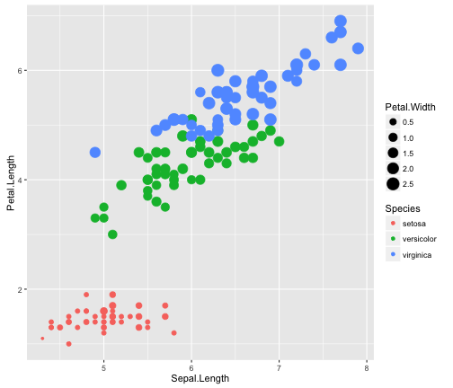

```r
library(ggplot2)
qplot(Sepal.Length, Petal.Length, data = iris, color = Species, size = Petal.Width)
```

## Rapid Data Exploration with dplyr and ggplot

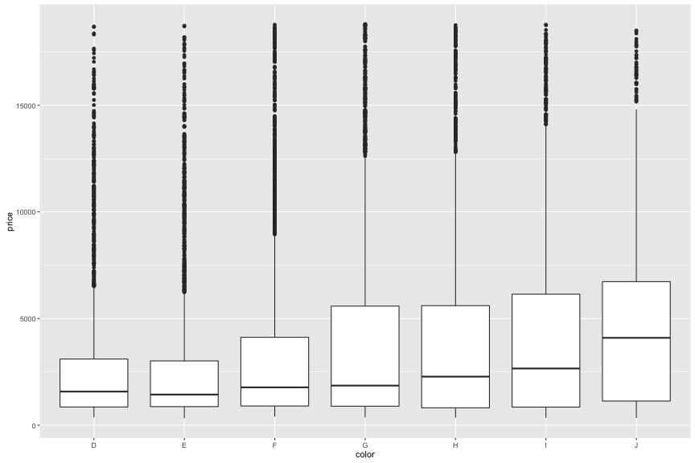

```r
diamonds %>%                      # Start with the 'diamonds' dataset
  filter(cut == "Ideal") %>%      # Then, filter down to rows where cut == Ideal
  ggplot(aes(x=color,y=price)) +  # Then, plot using ggplot
    geom_boxplot()                #  with and create a boxplot
```

# 1. (Individual, 100 pt)

```r
# 檔案放在："https://github.com/loperntu/dsR/blob/gh-pages/lectures/07/birth2006.csv" 有 31.1 MB, 也可以直接下載後再讀入
birth <- tbl_df(read.csv("birth2006.csv", row.names = 1))
```

> 資料說明: `birth2006.csv`檔，包含了 427323 筆紀錄，與 13 筆變量。變量的意義如下：
> - `DOB_MM` and `DOB_WK` : 出生的月份與星期。
> - `DBWT` : 北鼻的重量。
> - `WTGAIN`：母親妊娠期北鼻的增加重量。
> - `SEX` AND `APGAR5`：北鼻的性別和 APGAR5 分數。
> - `DPLURAL` ：胎數
> - `ESTGEST`：預估的懷孕週數。
> - `DMETH_REC`：剖腹產(c-section) 或自然產(vaginal)

#### 探索分析

- 經過基本審視資料，可以發現 *在週日出生的北鼻比週間還少*, 請用程式產生數據說明這個事實，並且做出以適當的圖形。
- 對於上述事實有個猜想是大部分的生產方式都是採「剖腹產」，而通常「剖腹產」的手術較少排在週日。請用程式產生數據說明這個事實。
- 如果我們要用圖形初步探索以下的變量之間是否有關聯，要如何利用`ggplot2`作圖?
  - *胎數與生產方式與北鼻體重*
  - *北鼻的體重成長與出生時重量*

# 2. (Group, 20 pt bonus)

- 找政府的開放資料(可嘗試各種類型:CSV/XML/JSON)，讀入並利用 `dplyr` + `ggplot2` 做 Exploratory Data Aanalysis. [參考](http://www.idealyzt.com/%E5%A6%82%E4%BD%95%E4%BD%BF%E7%94%A8-r-%E5%8F%96%E5%BE%97%E9%96%8B%E6%94%BE%E8%B3%87%E6%96%99/)

```r
# for zipped data (tested on MAC)
download.file("http://data.gov.tw/...",destfile = "test.zip", mode='wb')
unzip(zipfile="test.zip")
```

# 3. (預習：`ggplot()`)

中文資料參考

http://molecular-service-science.com/2013/11/27/r-ggplot-tutorial-1/

http://molecular-service-science.com/2014/01/23/r-ggplot-tutorial-2/